# final_project

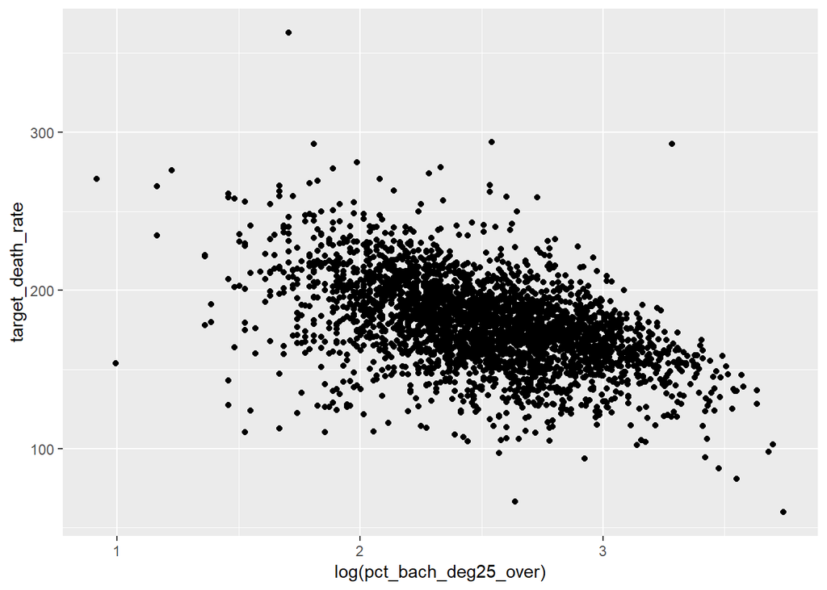

```r
## looks a little curvilinear

cancer_data %>%
  ggplot(aes(x = log(pct_bach_deg25_over), y = target_death_rate)) +
  geom_point()
```

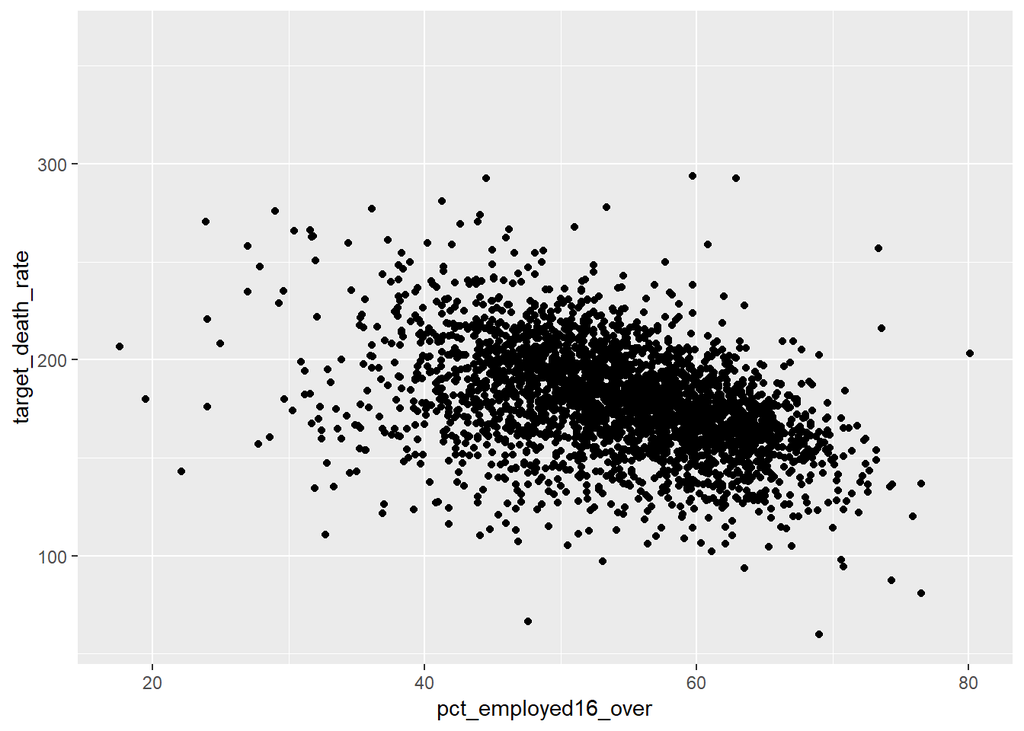

```r
## looks good

cancer_data %>%
  ggplot(aes(x = pct_employed16_over, y = target_death_rate)) +
  geom_point()
```

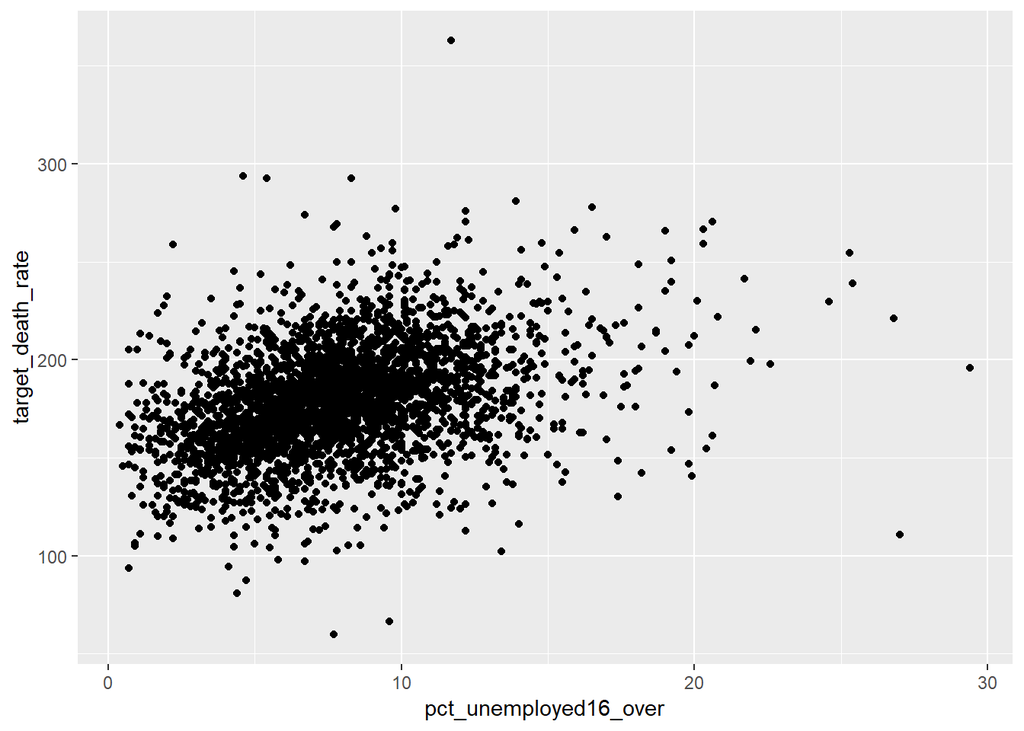

```r
## looks linear

cancer_data %>%
  ggplot(aes(x = pct_unemployed16_over, y = target_death_rate)) +
  geom_point()
```

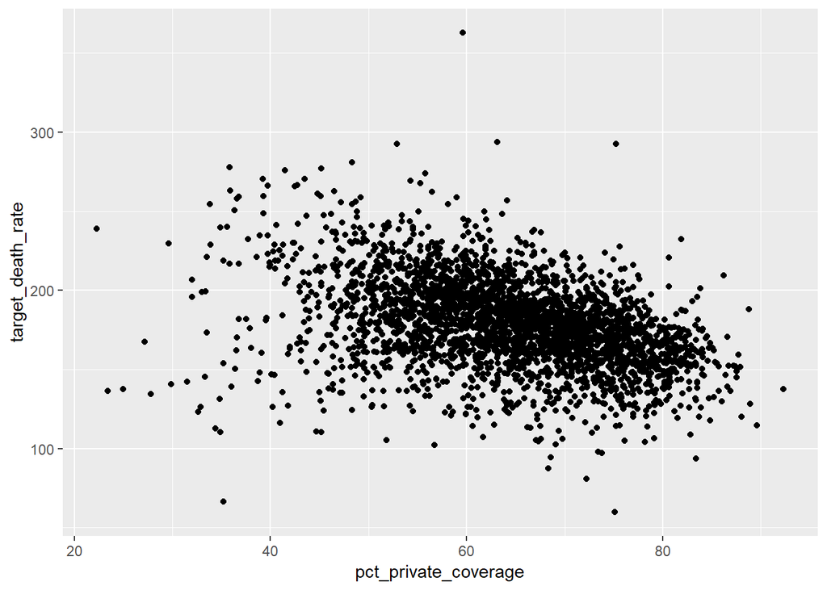

```r
## looks linear

cancer_data %>%
  ggplot(aes(x = pct_private_coverage, y = target_death_rate)) +
  geom_point()
```

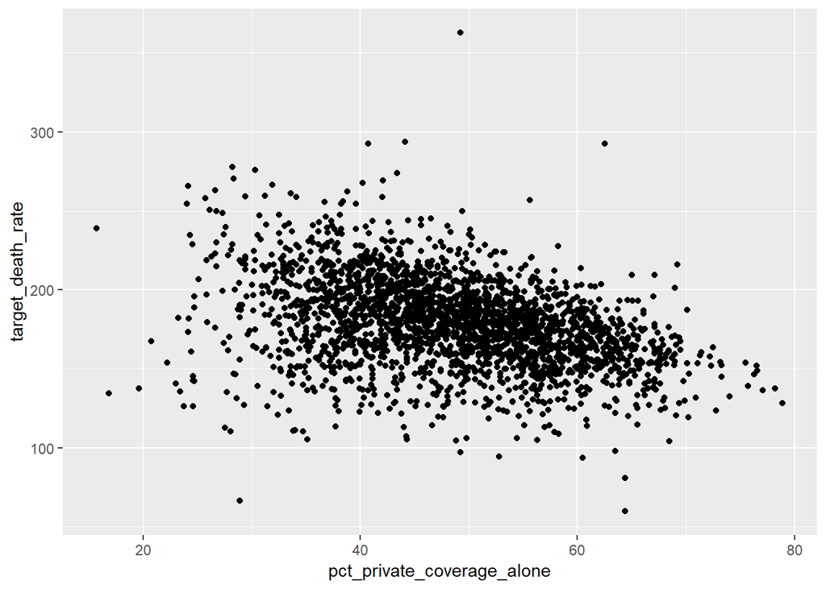

```r
## looks linear

cancer_data %>%
  ggplot(aes(x = pct_private_coverage_alone, y = target_death_rate)) +
  geom_point()
```

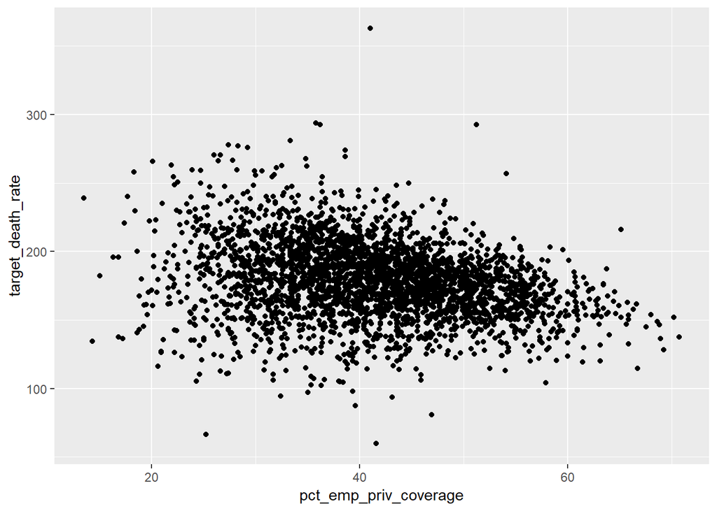

```r
## looks linear

cancer_data %>%
  ggplot(aes(x = pct_emp_priv_coverage, y = target_death_rate)) +
  geom_point()
```

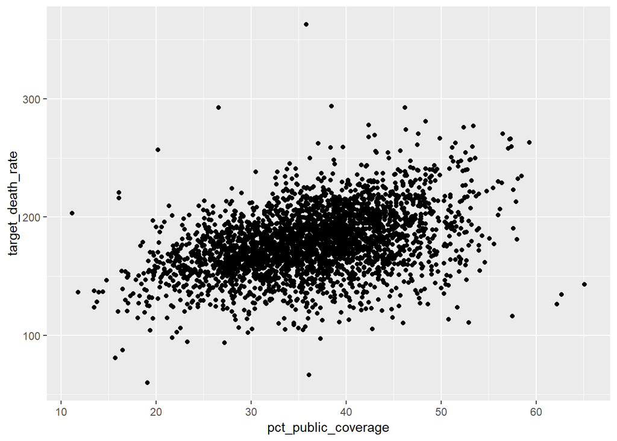

```r
## looks linear but also heteroscedastic

cancer_data %>%
  ggplot(aes(x = pct_public_coverage, y = target_death_rate)) +
  geom_point()
```

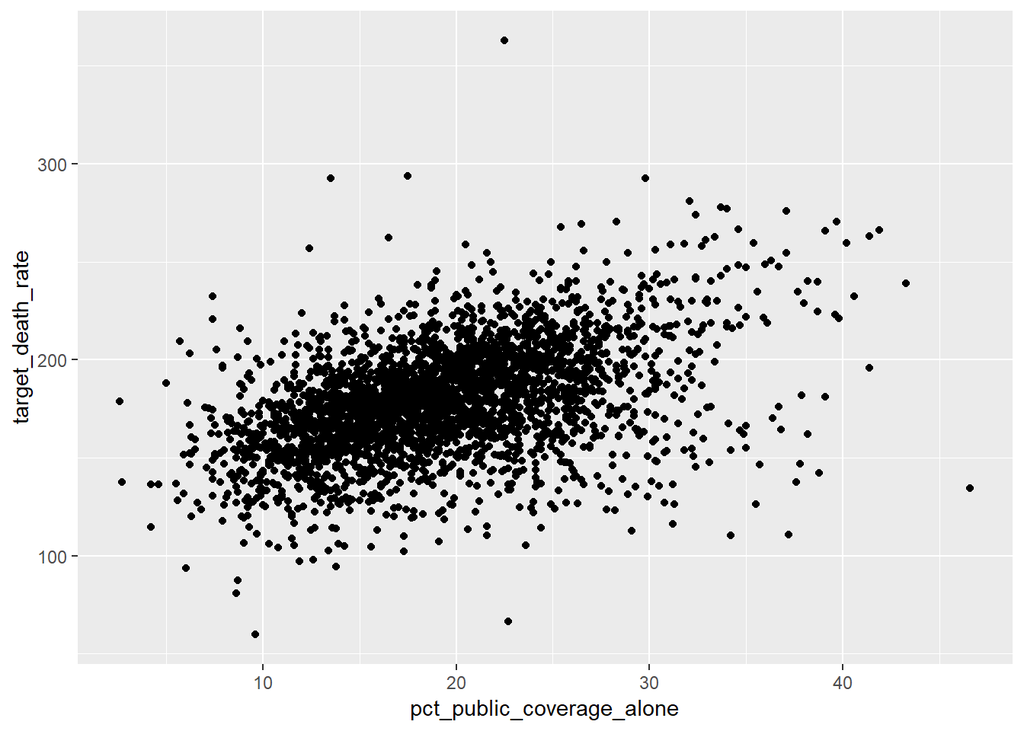

```r
## looks linear

cancer_data %>%
  ggplot(aes(x = pct_public_coverage_alone, y = target_death_rate)) +
  geom_point()
```

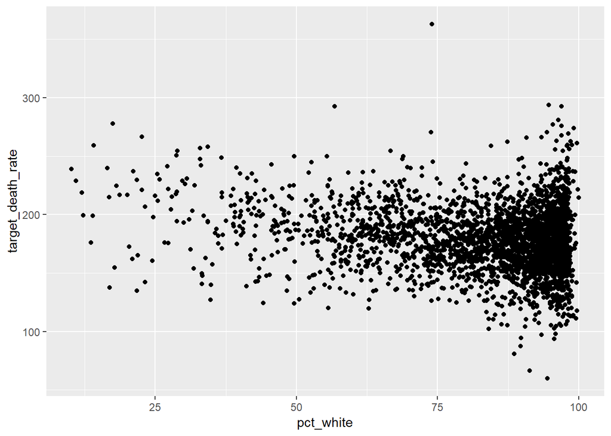

```r
## looks linear

cancer_data %>%
  ggplot(aes(x = pct_white, y = target_death_rate)) +
  geom_point()
```

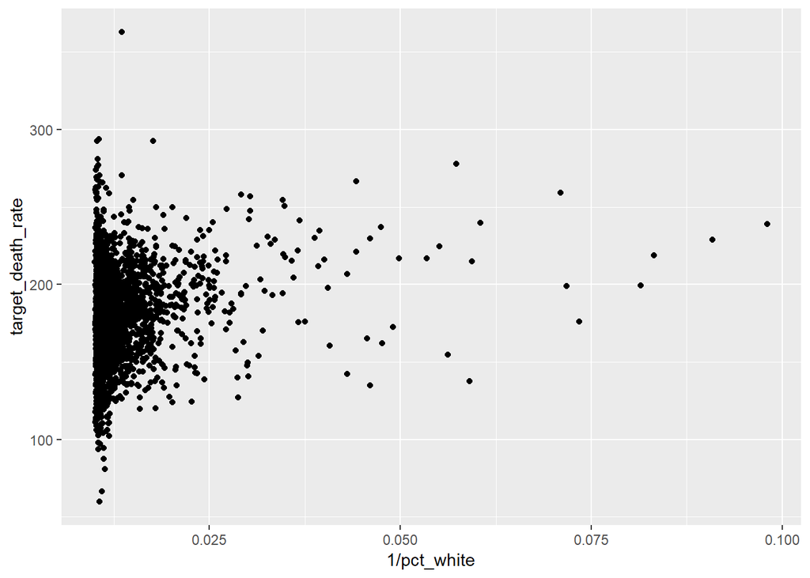

```r
## log transformation needed


cancer_data %>%
  ggplot(aes(x = 1/pct_white, y = target_death_rate)) +
  geom_point()
```

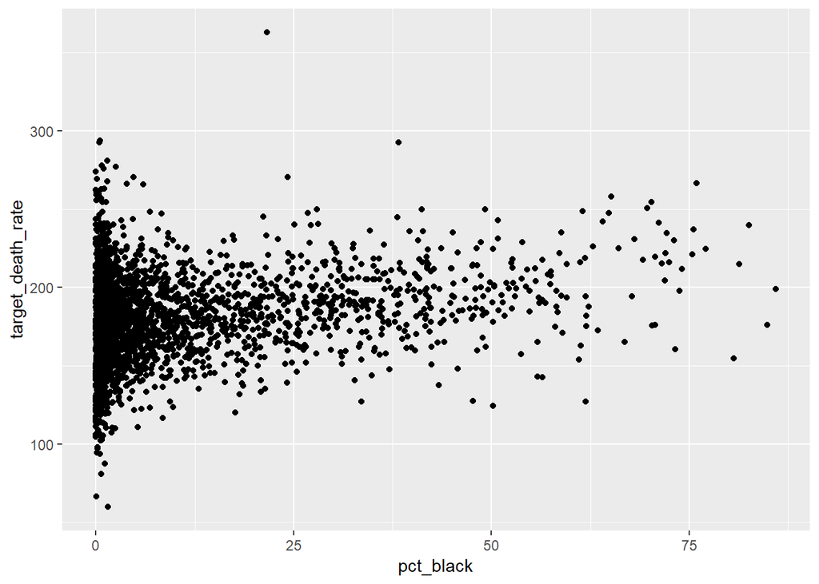

```r
## does not look linear, log, inverse and quadratics don't work

cancer_data %>%
  ggplot(aes(x = pct_black, y = target_death_rate)) +
  geom_point()
```

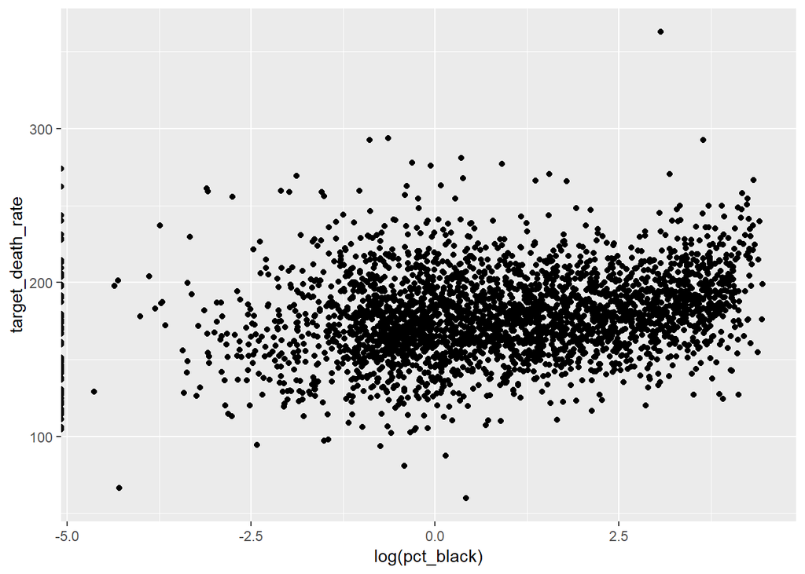

```r
## need tranformation


cancer_data %>%
  ggplot(aes(x = log(pct_black), y = target_death_rate)) +
  geom_point()
```

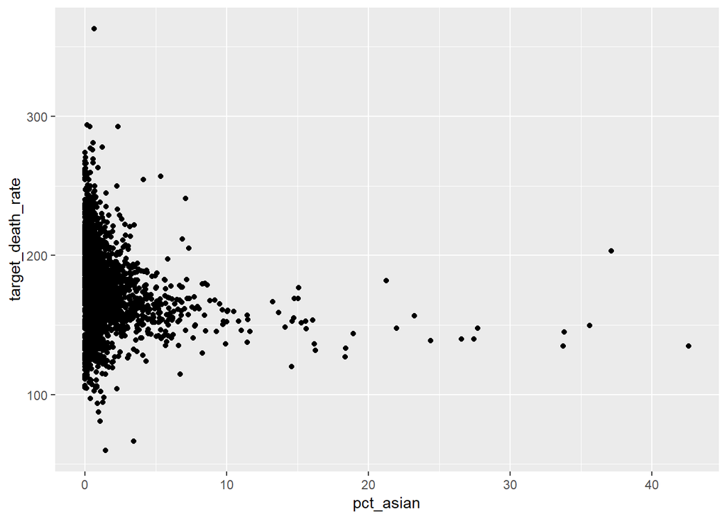

```r
## log looks better, but negative values may be an issue


cancer_data %>%
  ggplot(aes(x = pct_asian, y = target_death_rate)) +
  geom_point()
```

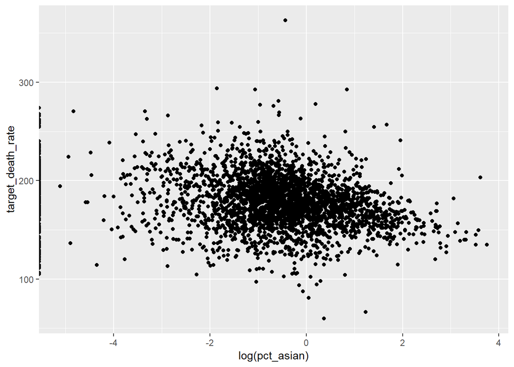

```r
## need transformation

cancer_data %>%
  ggplot(aes(x = log(pct_asian), y = target_death_rate)) +
  geom_point()
```

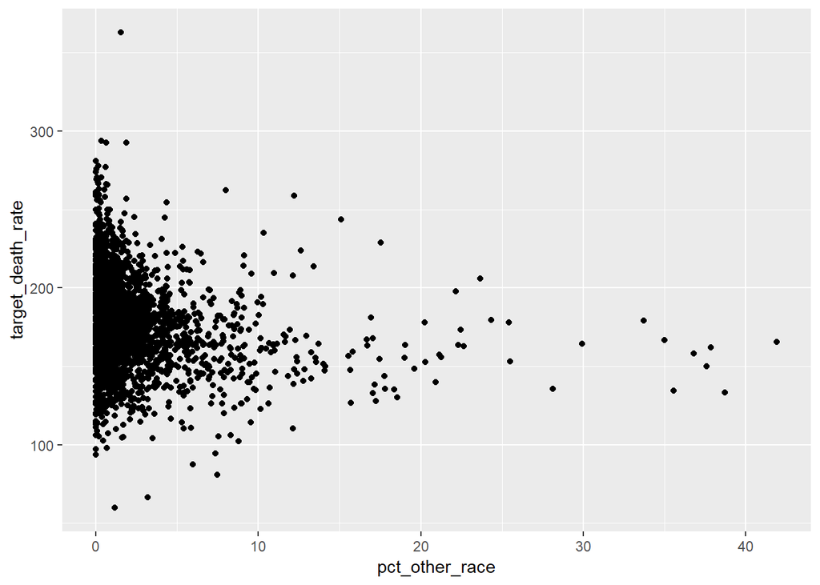

```r
## log looks better, but negative values may be an issue

cancer_data %>%
  ggplot(aes(x = pct_other_race, y = target_death_rate)) +
  geom_point()
```

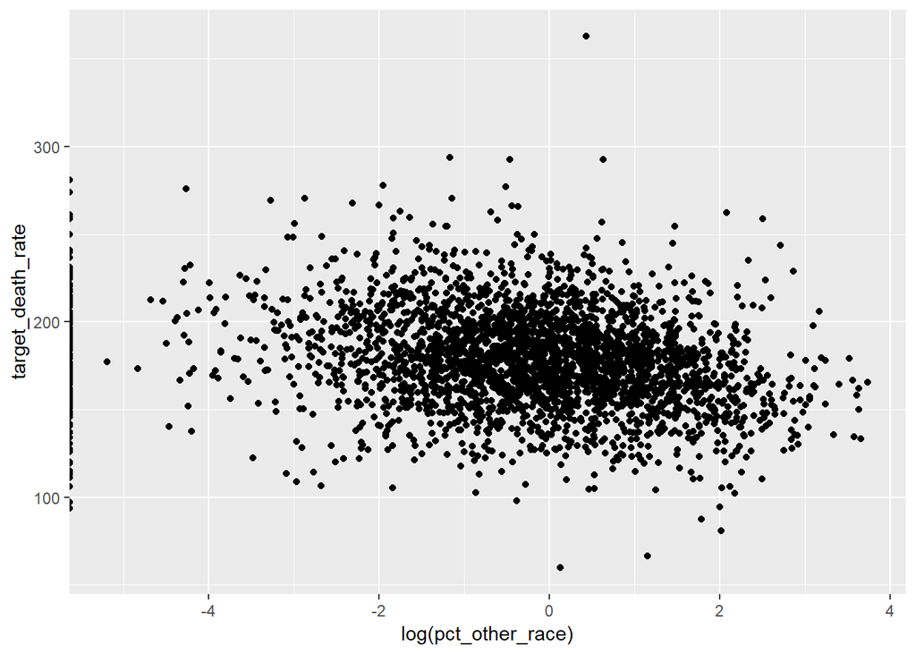

```r
## need transformation

cancer_data %>%
  ggplot(aes(x = log(pct_other_race), y = target_death_rate)) +
  geom_point()
```

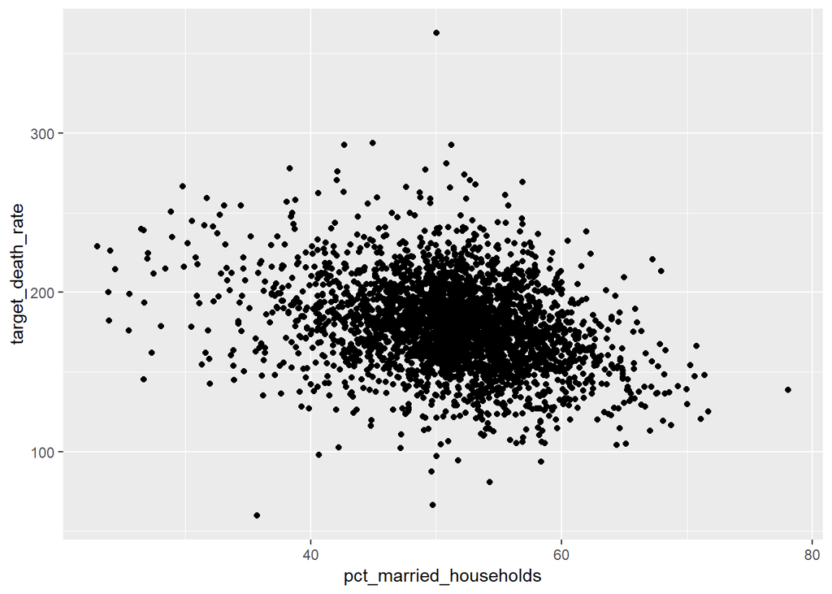

```r
## log looks better, but negative values may be an issue

cancer_data %>%
  ggplot(aes(x = pct_married_households, y = target_death_rate)) +
  geom_point()
```

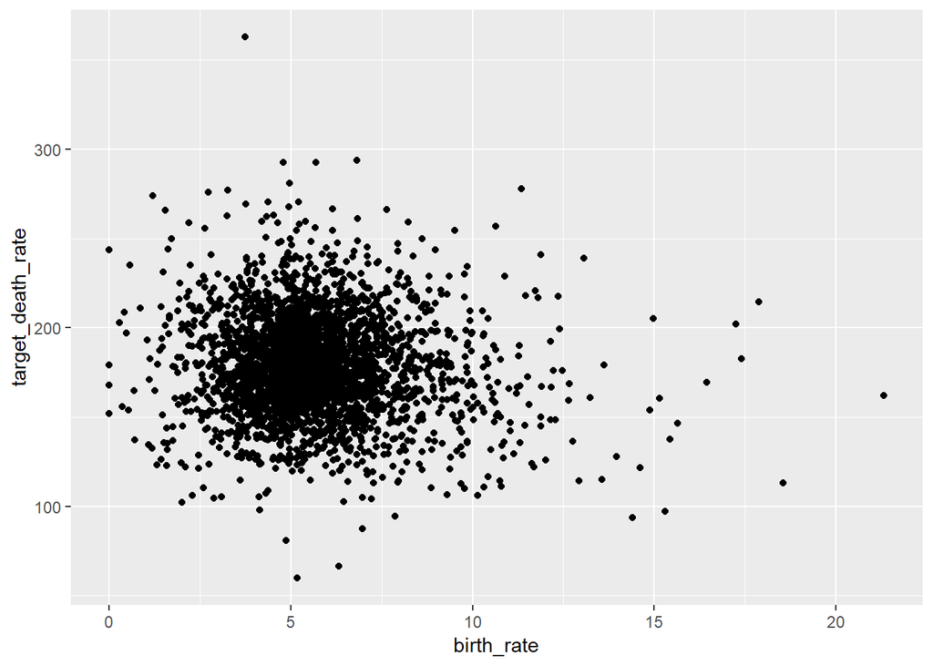

```r
## looks linear

cancer_data %>%
  ggplot(aes(x = birth_rate, y = target_death_rate)) +
  geom_point()
```

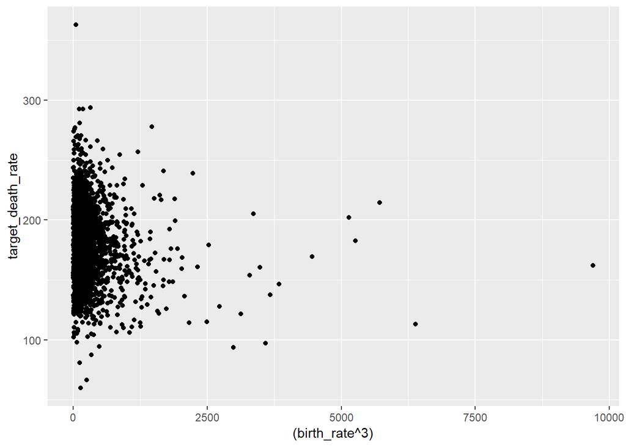

```r
## data points are a cluster


cancer_data %>%
  ggplot(aes(x = (birth_rate^3), y = target_death_rate)) +
  geom_point()
```

```r
## transformations don't really work
```

## Non linear variables

- avg_ann_count (transformations don’t work)
- avg_deaths_per_year (transformations don’t work)
- med_income (inverse transformation worked)
- study_per_cap (log transformation worked, but still has weird 0 values)
- median_age_male (transformations don’t work)
- percent_married (squared works)
- pct_no_hs18_24 (potentially curvlinear, squared/log do not work)
- pct_bach_deg18_24 (log makes a little better, but zeros are an issue)
- pct_bach_deg25_over (log works)
- pct_white (transformation don’t work)
- pct_black (log works, but negative values clustered)
- pct_asian (log works, but negative values clustered)
- birth_rate (all values are clustered)

## Variables with data quality concerns

- median_age (median ages of 300 - 600)

## Other things to note:

- incidence_rate has some extreme x outliers
- avg_household_size lots of median households of 0.02 size… not sure what this means